# Automated download of EU laws with scRapEU

Michele Scotto di Vettimo

2025-12-31

## General information

The dataset of EU laws downloaded with scRapEU contains 5746 distinct procedures initiated between 1992-09-02 and 2025-12-10.

The following table shows the number of procedures by decision procedure used and status:[^1]

|  | #Total | Completed | Pending | Withdrawn |
| --- | --- | --- | --- | --- |
| procedure_type |  |  |  |  |
| APP | 55 | 29 | 19 | 7 |
| AVC | 179 | 159 | 19 | 1 |
| CNS | 2588 | 2260 | 275 | 53 |
| COD | 2811 | 2375 | 273 | 163 |
| SYN | 113 | 109 | 4 |  |
| #Total cases | 5746 | 4932 | 590 | 224 |

Note that in all tables if the value reported under “#Total” does not coincide with the number of distinct procedures, it means that there are some missing values on the variables used in the table (see below the section “Information on missing data”). In the current stage of development, there are 0 missing instance for the type of procedure, 29 for the legal instrument, and 0 for the status of the procedure.

The table below reports the row percentages, by grouping variable:

|  | #Total | Completed | Pending | Withdrawn |
| --- | --- | --- | --- | --- |
| procedure_type |  |  |  |  |
| APP | 100 | 52.7 | 34.5 | 12.7 |
| AVC | 100 | 88.8 | 10.6 | 0.6 |
| CNS | 100 | 87.3 | 10.6 | 2.0 |
| COD | 100 | 84.5 | 9.7 | 5.8 |
| SYN | 100 | 96.5 | 3.5 |  |
| #Total cases | 5746 | 4932 | 590 | 224 |

The figure below shows the trend over time of the usage of a particular decision-making procedure:

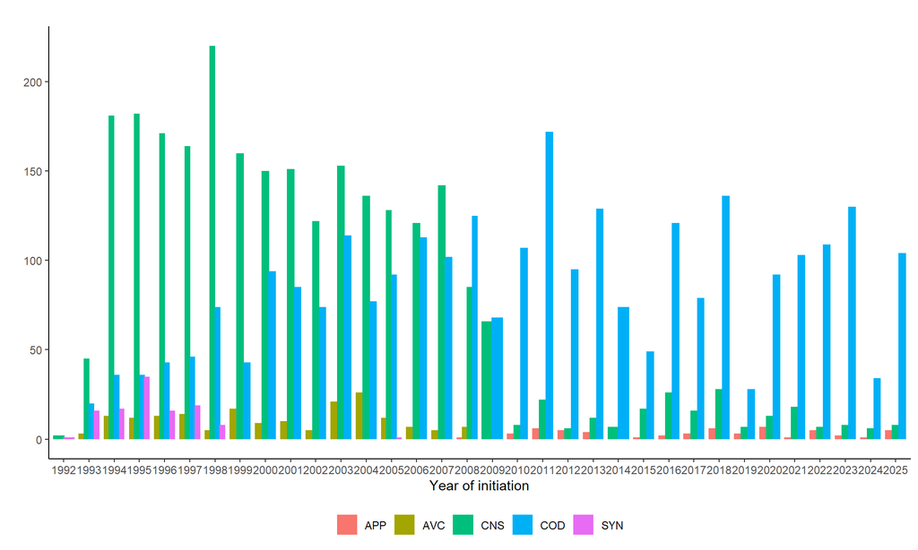

The following figure shows the distribution of the main legal instruments over time:

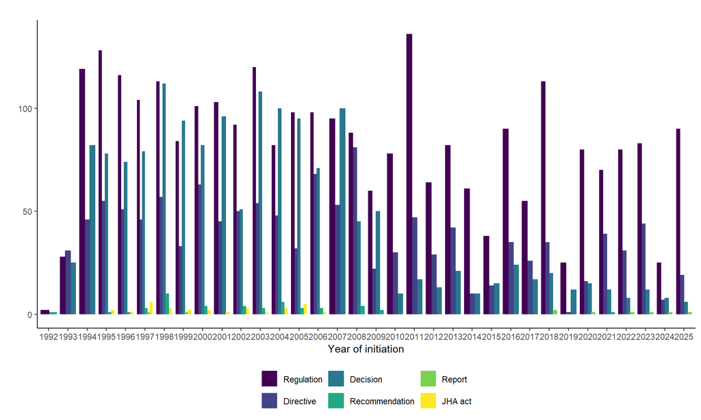

## Links to textual information extracted

There are 216 procedures for which it has not been possible to retrieve the identifier of the summary of the initiating document. Among the 4932 completed procedures, 0 are missing the identifier summary of the final act.

[^1]: The types of procedures have been grouped using the macro-categories available on the OEIL website. Namely, “Ordinary” legislative procedure contains “COD” acts, “Special” legislative procedure contains “CNS”, “APP”, “AVC”, and “SYN” acts, “Budget” procedures are “BUD”, “DEC”, and “BUI”, “Non-legislative” procedure is “NLE”, “EP Initiatives” contains “INL”, “INI”, “RSP”, “DCE”, and “COS”, “EP Internal” procedures are “REG”, “IMM”, and “RSO”, and, finally, “Quasi-legislative” procedures are “INS”, “ACI”, “DEA”, and “RPS”. In this report, only COD, CNS, SYN, APP, and AVC are included